# 時序期末報告

2018/6/12

股價是否能被預測, 一直存在著正反兩派的觀點。在參加趨勢科技舉辦的台灣ETF價格預測競賽之餘，嘗試利用時序的方法來預測股價。挑選其中一支比賽的基金股價(收盤價)來作為此次期末報告題目。

# 1 Dataset 介紹

台股代號0051的元大台灣中型100ETF成立於2006年8月24日，追蹤台灣證券交易所與FTSE合作編製的台灣中型100指數。台灣中型100指數由台股中市值排名第51到150這100家公司組成。

資料的colname 有時間(date)、股票名稱(name)、開盤價(op)、最大值(maxp)、最小值(minp)、收盤價(cp)和交易張數(trading)。

需要預測的變數為收盤價(cp)，往後都只考慮收盤價的時間序列性質。

```r
setwd("C:\\Users\\yifor\\Desktop\\台灣ETF價格預測競賽")
dat1 <- read.csv("tetfp.csv")
colnames(dat1)= c("id","date","name","op","maxp","minp","cp","trading")
dat1$trading = as.numeric( gsub(",","",dat1$trading))
dat1$date =  ymd(dat1$date)
dat1 = dat1 %>% filter(id==51)
dat1
```

| id | date | name | op | maxp | minp | cp | trading |
| --- | --- | --- | --- | --- | --- | --- | --- |
| 51 | 2013-01-02 | 元大中型100 | 25.75 | 26.10 | 25.75 | 26.09 | 277 |
| 51 | 2013-01-03 | 元大中型100 | 26.20 | 26.30 | 26.10 | 26.12 | 139 |
| 51 | 2013-01-04 | 元大中型100 | 26.12 | 26.12 | 25.74 | 26.00 | 88 |
| 51 | 2013-01-07 | 元大中型100 | 25.90 | 25.91 | 25.82 | 25.84 | 39 |
| 51 | 2013-01-08 | 元大中型100 | 25.84 | 25.84 | 25.64 | 25.68 | 33 |
| 51 | 2013-01-09 | 元大中型100 | 25.68 | 26.00 | 25.67 | 25.78 | 42 |
| 51 | 2013-01-10 | 元大中型100 | 25.86 | 26.12 | 25.86 | 25.98 | 149 |
| 51 | 2013-01-11 | 元大中型100 | 26.10 | 26.30 | 26.10 | 26.18 | 280 |
| 51 | 2013-01-14 | 元大中型100 | 26.18 | 26.18 | 26.00 | 26.18 | 88 |
| 51 | 2013-01-15 | 元大中型100 | 26.18 | 26.18 | 25.90 | 25.90 | 48 |

[output cut: 1317 more lines]

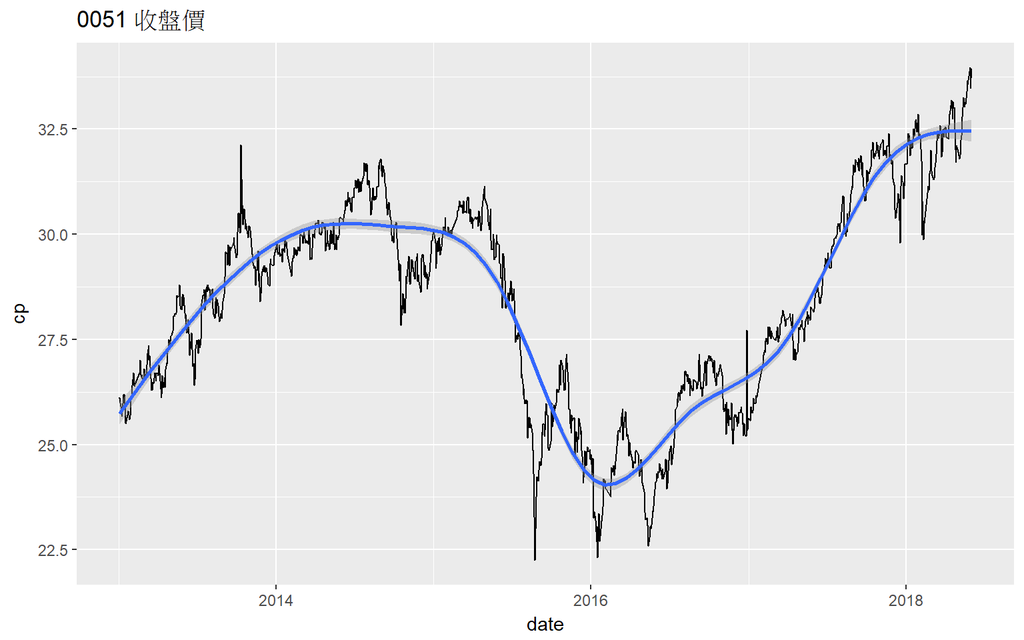

```r
dat1 %>% select(date,cp) %>%  ggplot( aes(x=date,y=cp)) + geom_line() +
  ggtitle("0051 收盤價") + geom_smooth()
```

# 2 初步分析

首先觀察這個資料的acf和pacf圖

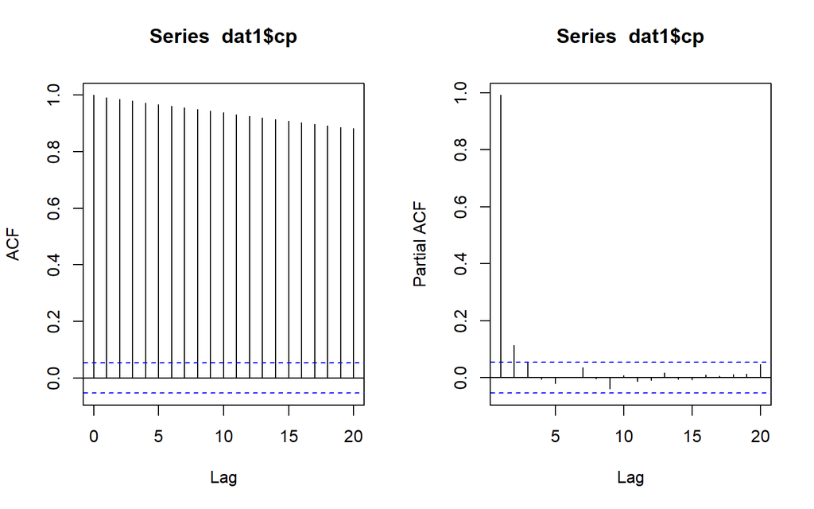

```r
par(mfrow=c(1,2))
acf(dat1$cp,lag=20)
pacf(dat1$cp,lag=20)
```

由acf圖可知此序列為非穩定的時間序列，因此先考慮做一階差分。

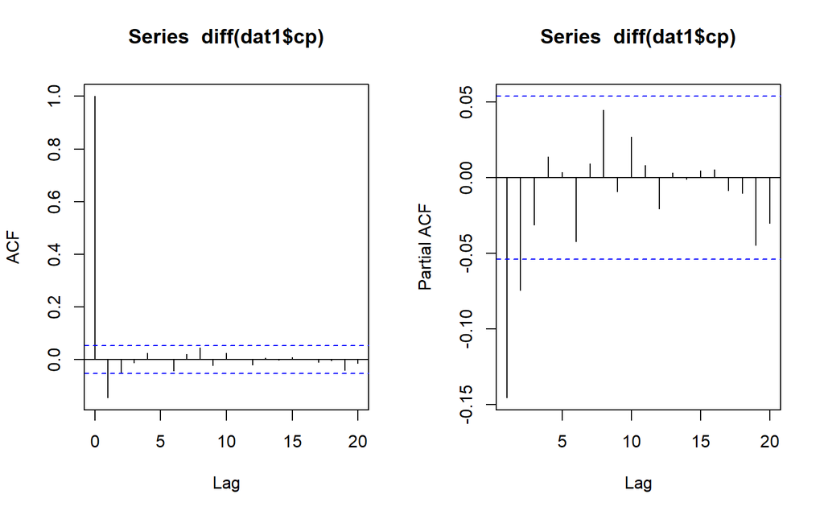

```r
par(mfrow=c(1,2))
acf(diff(dat1$cp),lag=20)
pacf(diff(dat1$cp),lag=20)
```

由一階差分的acf圖可看出在lag 2後cut off ，pacf圖也在lag 2後cut off。 考慮fit一個ARIMA(1,1,1)的model。

ARIMA(1,1,1) model 的係數如下:

```r
model1 = arima(dat1$cp, order = c(1, 1, 1)) ; model1
```

```
##
## Call:
## arima(x = dat1$cp, order = c(1, 1, 1))
##
## Coefficients:
##          ar1      ma1
##       0.2675  -0.4269
## s.e.  0.1334   0.1248
##
## sigma^2 estimated as 0.07702:  log likelihood = -181.76,  aic = 369.52
```

觀察ARIMA(1,1,1) model 的 residual plot

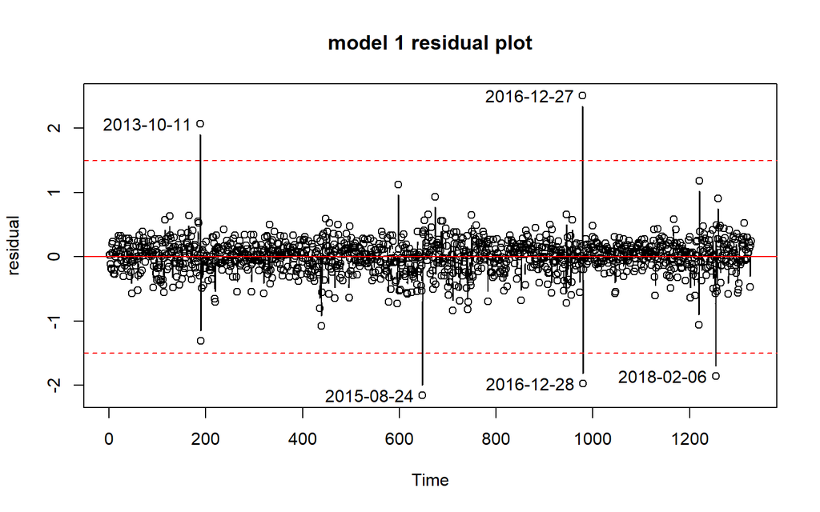

```r
plot(model1$residual, ylab = "residual",main="model 1 residual plot",type="b")
abline(h=c(-1.5,0,1.5),col=2,lty=c(2,1,2))
index = which(abs(model1$residuals)>1.5)
text(x=index-110,y=model1$residuals[index],labels =dat1$date[index])
```

可以看出在特定的時間residual非常大，猜測有重大事件發生。

| 日期 | 事件 |
| --- | --- |
| 2013/10/11 | 經濟日報 頭條—美債限僵局有解 美股狂飆 |
| 2015/08/24 | 經濟日報 頭條—救台股 禁止平盤以下放空 |
| 2016/12/27 | 漲停板 |
| 2018/02/06 | 經濟日報 美股崩跌逾千點 投資人起床以為自己眼花 |

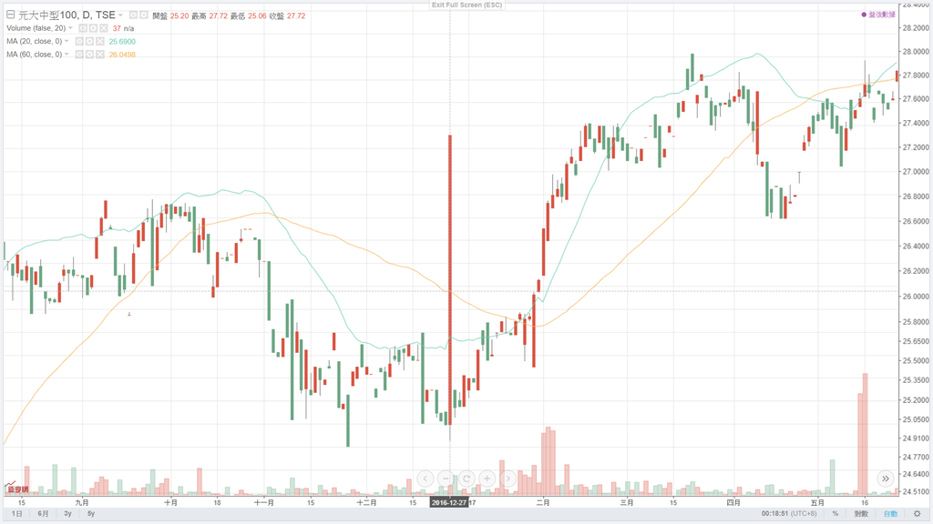

2016/12/27

檢查 residual plot 是否有序列相關性，先畫出acf和pacf圖。

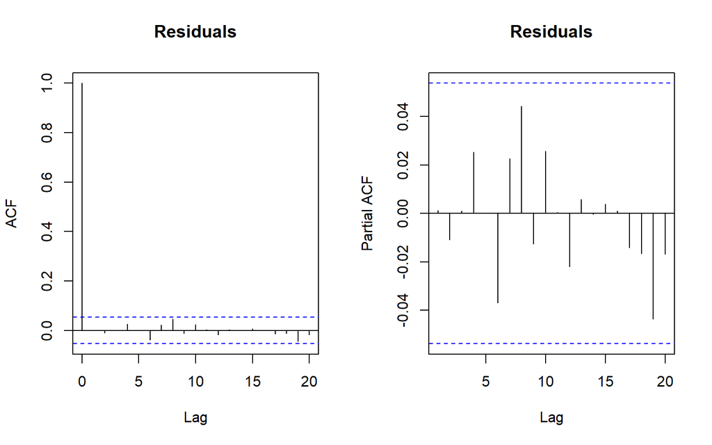

```r
par(mfrow = c(1, 2))
acf(c(model1$residual), main = "Residuals", lag = 20)
pacf(c(model1$residual), main = "Residuals", lag = 20)
```

使用Box-Ljung test

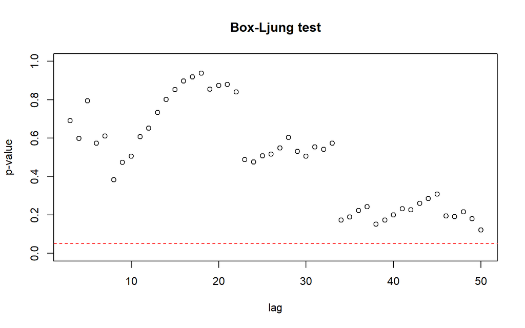

```r
a = 3:50
plot(a,sapply(a,function(i)  Box.test(c(model1$residual),lag = i,type = "Ljung", fitdf = 2)$p.value ),ylim = c(0,1),xlab = "lag",ylab = "p-value",main = "Box-Ljung test")
abline(h=0.05,col=2,lty=2)
```

檢定結果為不拒絕$\rho=0$在顯著水準$\alpha=0.05$下。

# 3 預測

使用 model 1 的 trainind set RMSE為0.2774123

```r
 accuracy(model1)
```

```
##                      ME      RMSE       MAE        MPE      MAPE     MASE
## Training set 0.00752727 0.2774123 0.1910226 0.01912015 0.6817681 1.009107
##                    ACF1
## Training set 0.00129656
```

Model 1 配適情形:

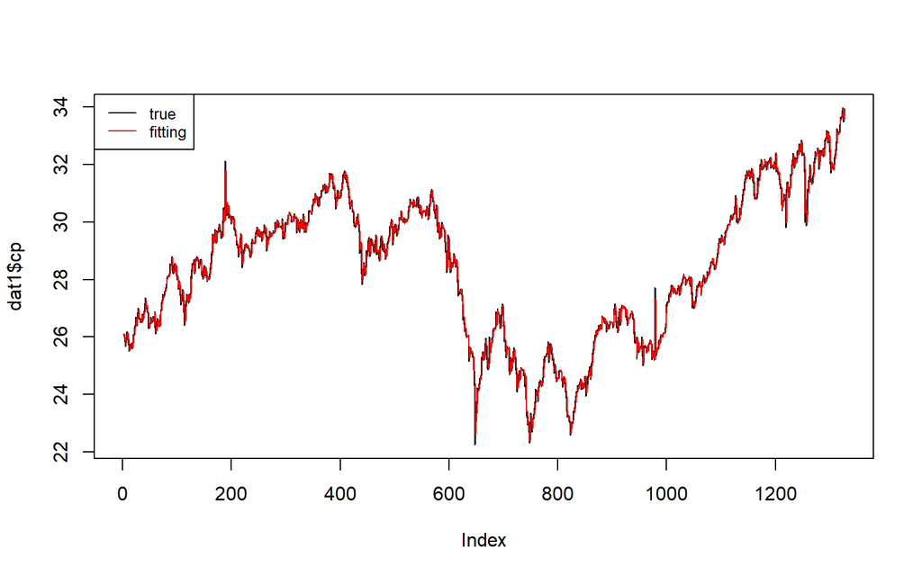

```r
k=forecast(model1, 5)
plot(dat1$cp,type="l")
points(k$fitted,col=2,type="l")
legend("topleft",legend=c("true","fitting"),col=c(1,2),lty=1,cex=0.8)
```

*使用model 1 的五步預測

```r
k1=forecast(model1, 5);k1
```

```
##      Point Forecast    Lo 80    Hi 80    Lo 95    Hi 95
## 1328       33.89897 33.54332 34.25463 33.35505 34.44290
## 1329       33.88800 33.42340 34.35260 33.17746 34.59855
## 1330       33.88507 33.34066 34.42947 33.05247 34.71767
## 1331       33.88428 33.27222 34.49634 32.94821 34.82035
## 1332       33.88407 33.21157 34.55657 32.85557 34.91257
```

| 預測結果 | 預測值 | 實際股價 |
| --- | --- | --- |
| 2018/6/4 | 33.89897 | 34.25 |
| 2018/6/5 | 33.88800 | 34.32 |
| 2018/6/6 | 33.88507 | 34.74 |
| 2018/6/7 | 33.88428 | 34.78 |
| 2018/6/8 | 33.88407 | 34.69 |

預測曲線 (虛線為95%區間)

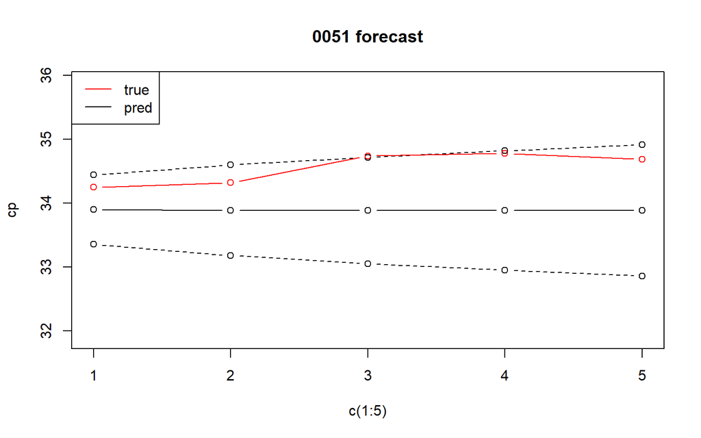

```r
true=c(34.25,   34.32,  34.74   ,34.78,34.69)
plot(c(1:5),k$mean,type="b",main="0051 forecast",ylim =c(min(k1$mean)-2,max(k1$mean)+2),ylab = "cp")
points(c(1:5),as.numeric( k1$lower[,2]),col=1,lty=2,type = "b")
points(c(1:5),as.numeric( k1$upper[,2]),col=1,lty=2,type = "b")
points(c(1:5),true,col=2,type="b")
legend("topleft",legend = c("true","pred"),col=c(2,1),lty=1,cex=1)
```

```r
sum((k1$mean-true)^2)/5
```

```
## [1] 0.4985174
```

mse 為 0.4985174

*fit 5個model (使用一步預測)

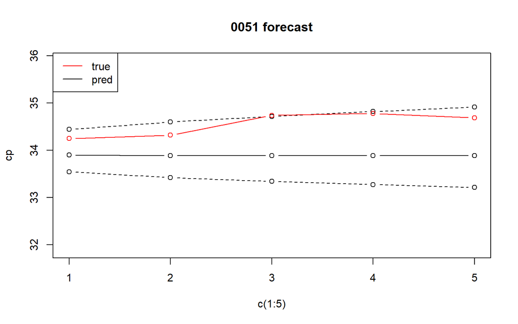

| 預測結果 | 預測值 | 實際股價 |
| --- | --- | --- |
| 2018/6/4 | 33.89897 | 34.25 |
| 2018/6/5 | 33.88798 | 34.32 |
| 2018/6/6 | 33.88503 | 34.74 |
| 2018/6/7 | 33.88424 | 34.78 |
| 2018/6/8 | 33.88403 | 34.69 |

```r
k2 = forecast(arima(c(dat1$cp,k1$mean[1]),order = c(1,1,1)),1)
k3 = forecast(arima(c(dat1$cp,k1$mean[1],k2$mean[1]),order = c(1,1,1)),1)
k4 = forecast(arima(c(dat1$cp,k1$mean[1],k2$mean[1],k3$mean[1]),order = c(1,1,1)),1)
k5 = forecast(arima(c(dat1$cp,k1$mean[1],k2$mean[1],k3$mean[1],k4$mean[1]),order = c(1,1,1)),1)

true=c(34.25,   34.32,  34.74   ,34.78,34.69)
plot(c(1:5),c(k1$mean[1],k2$mean[1],k3$mean[1],k4$mean[1],k5$mean[1]),type="b",main="0051 forecast",ylim =c(min(k$mean)-2,max(k$mean)+2),ylab = "cp")
points(c(1:5),as.numeric(k1$lower[,1],k2$lower[,1],k3$lower[,1],k4$lower[,1],k5$lower[,1]),col=1,lty=2,type = "b")
points(c(1:5),as.numeric(k1$upper[,2],k2$upper[,2],k3$upper[,2],k4$upper[,2],k5$upper[,2]),col=1,lty=2,type = "b")
points(c(1:5),true,col=2,type="b")
legend("topleft",legend = c("true","pred"),col=c(2,1),lty=1,cex=1)
```

```r
sum((c(k1$mean[1],k2$mean[1],k3$mean[1],k4$mean[1],k5$mean[1])-true)^2)/5
```

```
## [1] 0.498562
```

mse 為 0.498562